# ESM 206 Lab 5

Gabriel De La Rosa

10/28/2019

## Objectives:

- Getting counts for different groups
- Use {lubridate} to parse dates
- Find confidence intervals and do t-tests with t.test()
- Heatmap with geom_tile

```r
# Import lobster data

lobster_abundance <- read_csv(here::here("data", "lobster_abundance.csv"),
                              na = "-99999") %>%
  clean_names()
```

Our data isn’t in tidy format. Each lobster should have an individual row. The data is currently presented in a frequency table!

Let’s expand this using the tidyr::uncount function for lobster counts. This function drops NAs! Careful.

```r
lobster_tidy <- lobster_abundance %>%
  uncount(lobster_count)
```

Yay! Now each lobster has its own row. This is tidy format!

Let’s explore our data a bit:

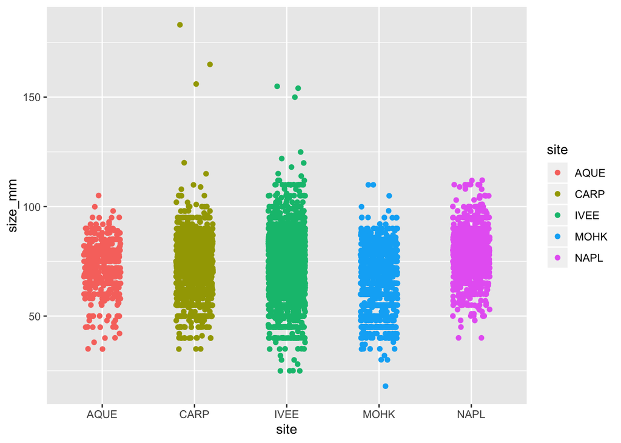

```r
ggplot(data = lobster_tidy, aes(x = site, y = size_mm)) +
  geom_jitter(aes(color = site),
              width = 0.2)
```

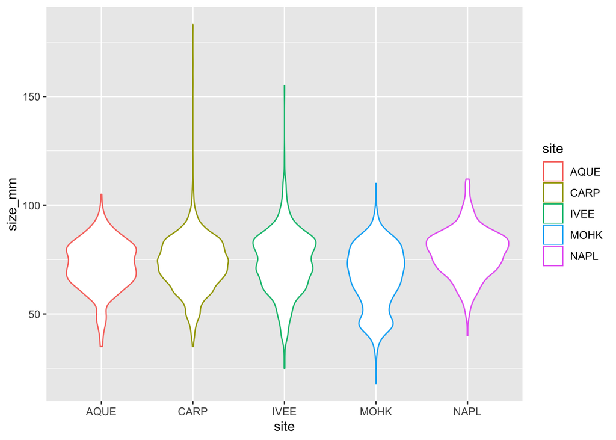

```r
## This isn't super informative. Looks like they have similar central tendency, different spread.
## Carp and IV look like they have outliers, maybe interesting.

ggplot(data = lobster_tidy, aes(x = site, y = size_mm)) +
  geom_violin(aes(color = site))
```

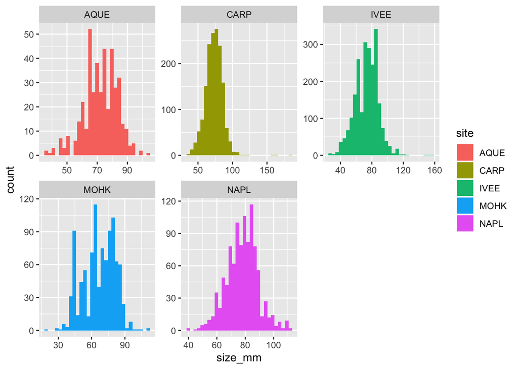

```r
# Violin plots are still hard to figure out skew, normality...

ggplot(data = lobster_tidy, aes(x = size_mm)) +
  geom_histogram(aes(fill = site)) +
  facet_wrap(~site, scales = "free")
```

```r
# scales = "free" changes individual scales for facets. Fine when looking at skew for sites.

# Histograms give us a good overview of skew.
```

These look relatively symmetrical, bell shaped, with one mode. Let’s look at a quantile-quantile plot, where bin width exerts no influence on our data…

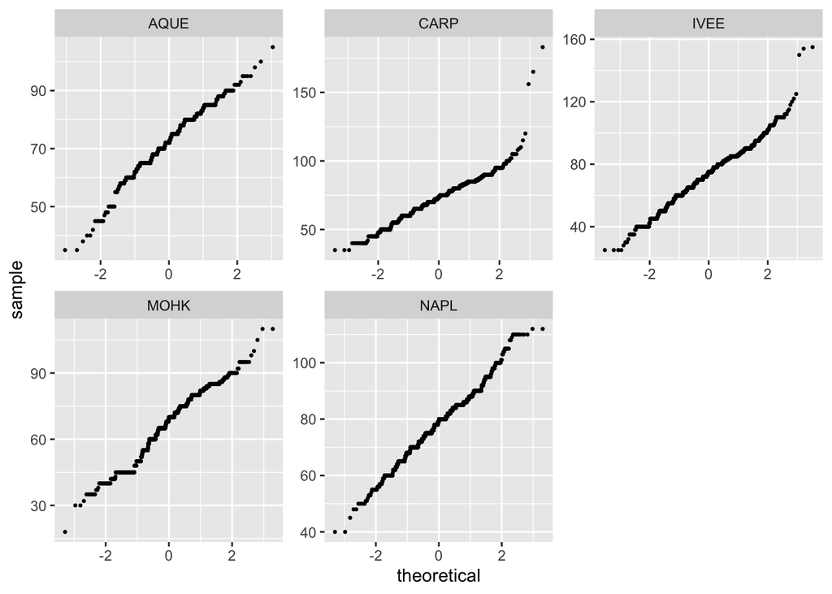

```r
# QQ plot with counts for each site...
# Need to specify what your sample mean is.

ggplot(data = lobster_tidy, aes(sample = size_mm)) +
  geom_qq(size = 0.5) +
  facet_wrap(~site, scales = "free")
```

Arroyo quemado looks normal. Carp looks like there’s a few higher than expected outliers, same with IV. Mohawke also looks fairly normal. It’s likely the histogram skewed the data with bin width. Naples looks very normal.

These are pretty normal across all groups!

But let’s explore this data a bit more…like by date!

Use “lubridate” to parse date and times: Always use lubridate:: because lubridate functions are redundant

Let’s add a new column with ‘mutate()’ that contains a date with an actual date

```r
# Let's get R to recognize dates as a date.
# Date currently stored as month / day / year (mdy). Remember this!

lobster_date <-  lobster_tidy %>%
  mutate(
    date_new = lubridate::mdy(date)
  )

# Both date format and variable class have changed.
```

Can we group this by months? Sure can!

Parse “date_new” column to get different pieces separated. label = TRUE gives you month abbreviation

```r
lobster_parse_date <- lobster_date %>%
  mutate (
    obs_month = lubridate::month(date_new, label = TRUE)
  ) %>%
  mutate (
    obs_year = lubridate::year(date_new)
  )
```

Nice!

Let’s ask a few question about counts of lobsters.

Count lobsters by different groupings…using dplyr::count!

Count calls on things using group_by, then counts those things in those groups.

Let’s say I want to count the number of lobsters by year and month.

```r
lobster_ym <- lobster_parse_date %>%
  count(obs_year, obs_month)

lobster_ym
```

```
## # A tibble: 8 x 3
##   obs_year obs_month     n
##      <dbl> <ord>     <int>
## 1     2012 Aug         231
## 2     2013 Aug         243
## 3     2014 Aug         404
## 4     2014 Sep         106
## 5     2015 Aug        1100
## 6     2016 Aug         809
## 7     2017 Aug        1668
## 8     2018 Aug        1805
```

```r
# What about counting for each site?

lobster_ysite <- lobster_parse_date %>%
  count(obs_year, site)

lobster_ysite
```

```
## # A tibble: 35 x 3
##    obs_year site      n
##       <dbl> <chr> <int>
##  1     2012 AQUE     38
##  2     2012 CARP     78
##  3     2012 IVEE     26
##  4     2012 MOHK     83
##  5     2012 NAPL      6
##  6     2013 AQUE     32
##  7     2013 CARP     93
##  8     2013 IVEE     40
##  9     2013 MOHK     15
## 10     2013 NAPL     63
## # … with 25 more rows
```

```r
# What about counting just for site?

lobster_site <- lobster_parse_date %>%
  count(site)

lobster_site
```

```
## # A tibble: 5 x 2
##   site      n
##   <chr> <int>
## 1 AQUE    422
## 2 CARP   1619
## 3 IVEE   2304
## 4 MOHK    982
## 5 NAPL   1039
```

This is super important when considering sample sizes.

How do we find numbers of observations in a summary table? use group_by + summarize + n()

```r
lobster_summary <- lobster_parse_date %>%
  group_by (site) %>%
  summarize(
    mean_size = mean(size_mm, na.rm = TRUE),
    sd_size = sd(size_mm, na.rm = TRUE),
    sample_n = n()
  )
```

Count basically is better than tally. Don’t listen to tally people.

Let’s start looking at some confidence intervals and t-tests.

T distribution accounts for increased uncertainty with small sample sizes and population uncertainty.

Use the “t.test()” function to find confidence intervals and perform t-tests pull() stores values as a vector. Useful for some base r functions.

```r
# Let's find CI for lobster sizes at IV beach

ivee_lobsters <- lobster_tidy %>%
  filter(site == "IVEE") %>%
  pull(size_mm)

t.test(ivee_lobsters)
```

```
##
##  One Sample t-test
##
## data:  ivee_lobsters
## t = 245.23, df = 2302, p-value < 2.2e-16
## alternative hypothesis: true mean is not equal to 0
## 95 percent confidence interval:
##  72.99130 74.16806
## sample estimates:
## mean of x
##  73.57968
```

Okay, but let’s see if theres a significant difference in size between lobsters measured at naples and mowhawk reef

First, the tedious way…

```r
# Don't put just single means in! You need entire sample.

napl_sample <- lobster_tidy %>%
  filter(site == "NAPL") %>%
  pull(size_mm)

mohk_sample <- lobster_tidy %>%
  filter(site == "MOHK") %>%
  pull(size_mm)

mohk_napl_ttest <- t.test(mohk_sample, napl_sample)

mohk_napl_ttest
```

```
##
##  Welch Two Sample t-test
##
## data:  mohk_sample and napl_sample
## t = -19.849, df = 1850.8, p-value < 2.2e-16
## alternative hypothesis: true difference in means is not equal to 0
## 95 percent confidence interval:
##  -12.43436 -10.19806
## sample estimates:
## mean of x mean of y
##  66.86833  78.18454
```

What does this mean? There is a 2.2 e -16 chance that if I took two random samples from a population with the same mean that I would get means this different. So, actually, what’s more likely is that the two sample populations were initially different.

Inline variable referencing:

Let’s make a statement about the t-test.

Mean lobster size differed significantly between Mohawk and Naples reefs (df(1850.7720862), t = -19.8487322)

But there’s an easier way!!

```r
# Create df with two groups you want to compare

lobster_2 <- lobster_tidy %>%
  filter(site == c("NAPL", "MOHK"))

ttest_2 <- t.test(size_mm ~ site, data = lobster_2)

ttest_2
```

```
##
##  Welch Two Sample t-test
##
## data:  size_mm by site
## t = -14.483, df = 926.81, p-value < 2.2e-16
## alternative hypothesis: true difference in means is not equal to 0
## 95 percent confidence interval:
##  -13.24265 -10.08206
## sample estimates:
## mean in group MOHK mean in group NAPL
##           66.59490           78.25725
```

Now, let’s make a geom_tile heatmap: Using lobster_ysite

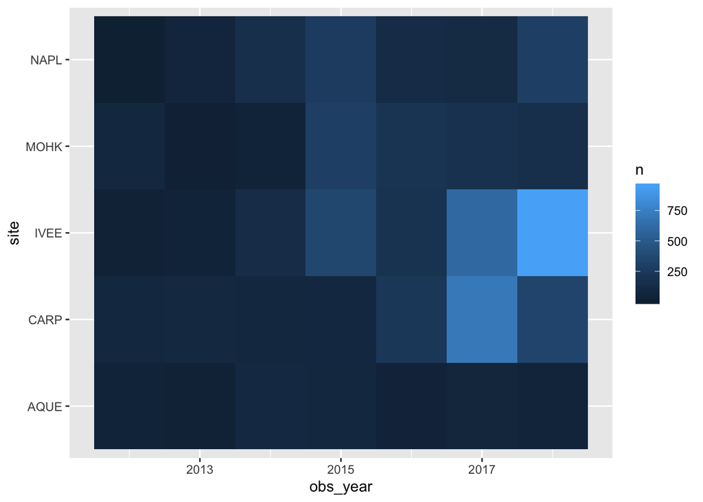

```r
ggplot(data = lobster_ysite, aes(x = obs_year, y = site)) +
  geom_tile(aes(fill = n))
```